# Visit With Us Procject

Observations

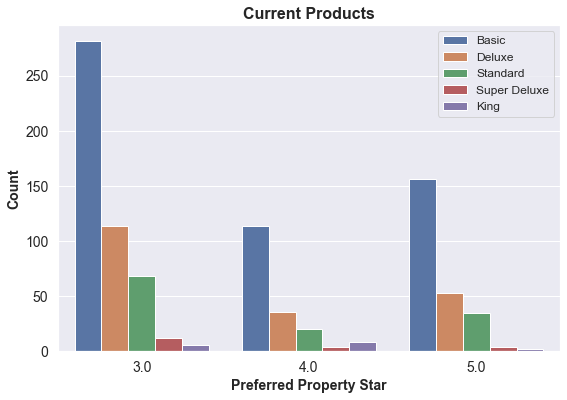

```python
# Current products
fig = plt.figure(figsize=[9,6]);
sns.countplot(data=dat_analysis, x='PreferredPropertyStar', hue='ProductPitched', hue_order=['Basic','Deluxe','Standard','Super Deluxe','King']);
plt.xticks(fontsize=14);
plt.xlabel('Preferred Property Star', fontsize=14, fontweight='bold');
plt.yticks(fontsize=14);
plt.ylabel('Count', fontsize=14, fontweight='bold');
plt.legend(fontsize=12);
plt.title('Current Products', fontsize=16, fontweight='bold');
```

Observations

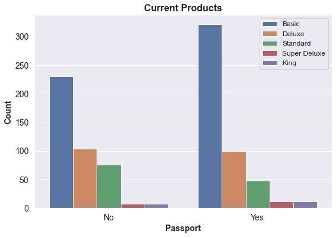

```python
fig = plt.figure(figsize=[9,6]);
sns.countplot(data=dat_analysis, x='Passport', hue='ProductPitched', hue_order=['Basic','Deluxe','Standard','Super Deluxe','King']);
plt.xticks([0,1], labels=['No','Yes'],fontsize=14);
plt.xlabel('Passport', fontsize=14, fontweight='bold');
plt.yticks(fontsize=14);
plt.ylabel('Count', fontsize=14, fontweight='bold');
plt.legend(fontsize=12);
plt.title('Current Products', fontsize=16, fontweight='bold');
```

Basic customers more likely to have a passport but equal for relatively equal chance for other packages.

Observations

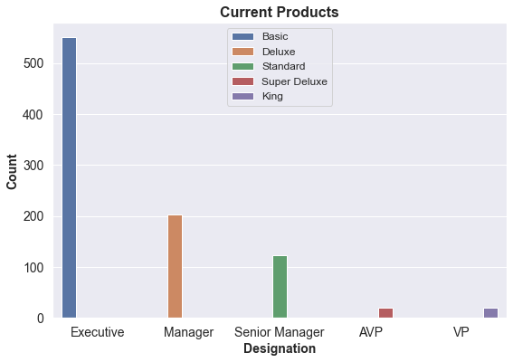

```python
# Plot Designation according to package
fig = plt.figure(figsize=[9,6]);
sns.countplot(data=dat_analysis, x='Designation', hue='ProductPitched',order=['Executive','Manager','Senior Manager','AVP','VP'], hue_order=['Basic','Deluxe','Standard','Super Deluxe','King']);
plt.xticks(fontsize=14);
plt.xlabel('Designation', fontsize=14, fontweight='bold');
plt.yticks(fontsize=14);
plt.ylabel('Count', fontsize=14, fontweight='bold');
plt.legend(fontsize=12);
plt.title('Current Products', fontsize=16, fontweight='bold');
```

This plot speaks for itself. Executives: Basic package, Manager: Deluxe Package, Senior Manager: Standard Package, AVP: Super Deluxe, VP: King. Real life isn't like this, but for the dataset provided, a customers Designation is all that would be needed to determine with level of package to pitch.

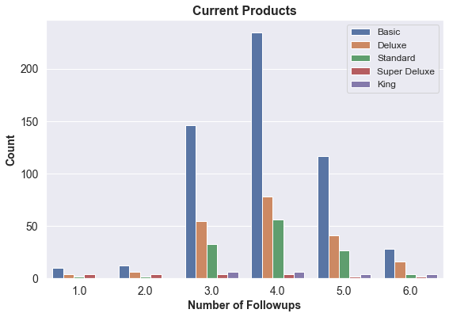

```python
# Number of Followups for cureen products
fig = plt.figure(figsize=[9,6]);
sns.countplot(data=dat_analysis, x='NumberOfFollowups', hue='ProductPitched', hue_order=['Basic','Deluxe','Standard','Super Deluxe','King']);
plt.xticks(fontsize=14);
plt.xlabel('Number of Followups', fontsize=14, fontweight='bold');
plt.yticks(fontsize=14);
plt.ylabel('Count', fontsize=14, fontweight='bold');
plt.legend(fontsize=12);
plt.title('Current Products', fontsize=16, fontweight='bold');
```

A majority of customers required 3-5 follow-ups before making a purchase.

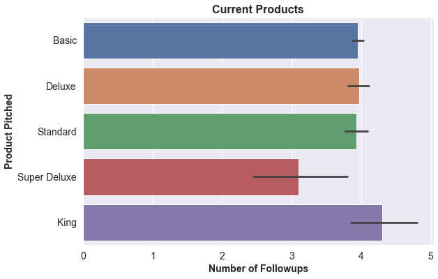

```python
# Number of Followups
fig = plt.figure(figsize=[9,6]);
sns.barplot(data=dat_analysis, x='NumberOfFollowups', y='ProductPitched', order=['Basic','Deluxe','Standard','Super Deluxe','King']);
plt.xticks(fontsize=14);
plt.xlabel('Number of Followups', fontsize=14, fontweight='bold');
plt.yticks(fontsize=14);
plt.ylabel('Product Pitched', fontsize=14, fontweight='bold');
plt.title('Current Products', fontsize=16, fontweight='bold');
```

Basic, Deluxe, and Standard packages on average required 4 follow-ups before purchase made. Super Deluxe on average required 3 follow ups before purchase made. And King on average required 4-5 follow-ups. ** there may be an indicator here on the Super Deluxe package performance - the lower than average follow-ups may indicate that low sales might be due to not following up enough.

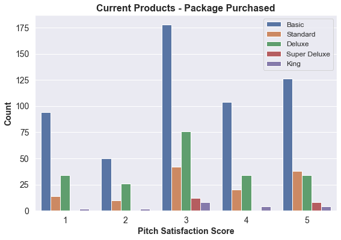

```python
# Pitch Satisfaction Score
fig = plt.figure(figsize=[9,6]);
sns.countplot(data=dat_analysis, x='PitchSatisfactionScore', hue='ProductPitched', hue_order=['Basic','Standard','Deluxe','Super Deluxe','King']);
plt.xticks(fontsize=14);
plt.xlabel('Pitch Satisfaction Score', fontsize=14, fontweight='bold');
plt.yticks(fontsize=14);
plt.ylabel('Count', fontsize=14, fontweight='bold');
plt.legend(fontsize=12);
plt.title('Current Products - Package Purchased', fontsize=16, fontweight='bold');
```

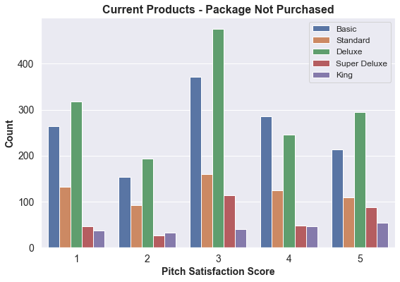

```python
# Pitch Satisfaction Score count plot
fig = plt.figure(figsize=[9,6]);
sns.countplot(data=df[df['ProdTaken']==0], x='PitchSatisfactionScore', hue='ProductPitched', hue_order=['Basic','Standard','Deluxe','Super Deluxe','King']);
plt.xticks(fontsize=14);
plt.xlabel('Pitch Satisfaction Score', fontsize=14, fontweight='bold');
plt.yticks(fontsize=14);
plt.ylabel('Count', fontsize=14, fontweight='bold');
plt.legend(fontsize=12);
plt.title('Current Products - Package Not Purchased', fontsize=16, fontweight='bold');
```

There does not appear to be much of a correlation between pitch satisfaction score and purchase. Maybe the customers didn't understand whether 1 or 5 were best or worst scores?

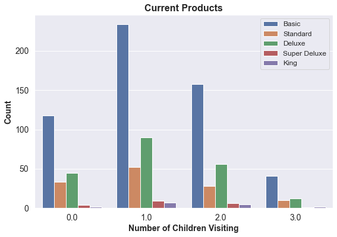

```python
# Number of Children Visiting yes or no
fig = plt.figure(figsize=[9,6]);
sns.countplot(data=dat_analysis, x='NumberOfChildrenVisiting', hue='ProductPitched', hue_order=['Basic','Standard','Deluxe','Super Deluxe','King']);
plt.xticks(fontsize=14);
plt.xlabel('Number of Children Visiting', fontsize=14, fontweight='bold');
plt.yticks(fontsize=14);
plt.ylabel('Count', fontsize=14, fontweight='bold');
plt.legend(fontsize=12);
plt.title('Current Products', fontsize=16, fontweight='bold');
```

People with more than 2 children were unlikely to purchase a travel package. A majority of customers had 1 or 2 children, though childless customers were also prevalent.

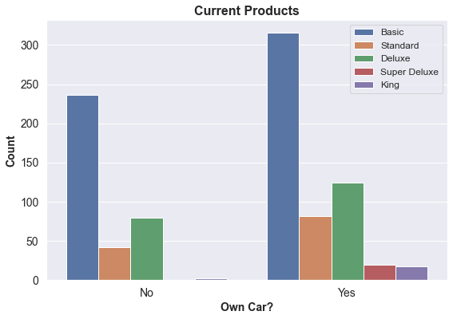

```python
# Own Car
fig = plt.figure(figsize=[9,6]);
sns.countplot(data=dat_analysis, x='OwnCar', hue='ProductPitched', hue_order=['Basic','Standard','Deluxe','Super Deluxe','King']);
plt.xticks([0,1],labels=['No','Yes'],fontsize=14);
plt.xlabel('Own Car?', fontsize=14, fontweight='bold');
plt.yticks(fontsize=14);
plt.ylabel('Count', fontsize=14, fontweight='bold');
plt.legend(fontsize=12);
plt.title('Current Products', fontsize=16, fontweight='bold');
```

Majority of customers own a car, but those that do not are likely to putchase lower end packages, especially the basic package.

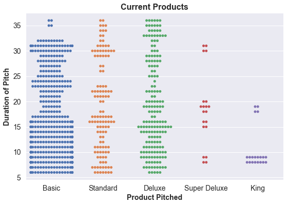

```python
# DurationOfPitch
fig = plt.figure(figsize=[9,6]);
sns.swarmplot(data=dat_analysis, y='DurationOfPitch', x='ProductPitched', order=['Basic','Standard','Deluxe','Super Deluxe','King']);
plt.xticks(fontsize=14);
plt.xlabel('Product Pitched', fontsize=14, fontweight='bold');
plt.yticks(fontsize=14);
plt.ylabel('Duration of Pitch', fontsize=14, fontweight='bold');
plt.title('Current Products', fontsize=16, fontweight='bold');
```

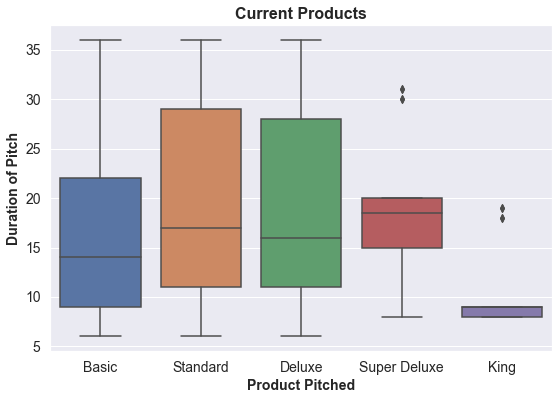

```python
fig=plt.figure(figsize=[9,6]);
sns.boxplot(data=dat_analysis, y='DurationOfPitch', x='ProductPitched', order=['Basic','Standard','Deluxe','Super Deluxe','King']);
plt.xticks(fontsize=14);
plt.xlabel('Product Pitched', fontsize=14, fontweight='bold');
plt.yticks(fontsize=14);
plt.ylabel('Duration of Pitch', fontsize=14, fontweight='bold');
plt.title('Current Products', fontsize=16, fontweight='bold');
```

A pitch duration of about 20 minutes is recommended for the Basic, Deluxe, Standard, and Super Deluxe packages for optimal sales performance. For the king package, it is recommended that pitch length be apprimately 10 minutes but not more than 15 minutes.

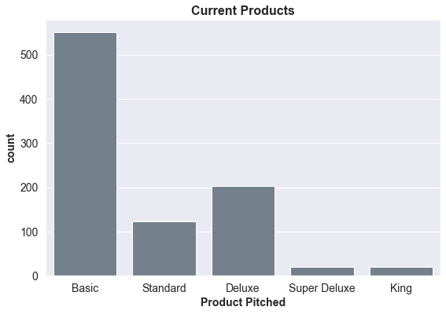

```python
fig=plt.figure(figsize=[9,6]);
sns.countplot(data=dat_analysis, x='ProductPitched', order=['Basic','Standard','Deluxe','Super Deluxe','King'], color='navy', label='Pitched');
sns.countplot(data=dat_analysis, x='ProductPitched', order=['Basic','Standard','Deluxe','Super Deluxe','King'], color='slategray', Label='Bought');
plt.xticks(fontsize=14);
plt.xlabel('Product Pitched', fontsize=14, fontweight='bold');
plt.yticks(fontsize=14);
plt.ylabel('count', fontsize=14, fontweight='bold');
plt.title('Current Products', fontsize=16, fontweight='bold');
```

The basic tranvel package has the highest conversion rate, at about 30% of total pitches, followed by the Standard at about 15%, then the Deluxe (10%) and King (8%). The super-deluxe package had the worst performance, though it is not clear why. It may be that the super deluxe package is not appealing to customers and should not be offered anymore, or the pitch needs to be improved upon and customers selected in a more methodical way. For all of the lower performing packages, it is recommended that their performance be further studied to find areas of improvement.

```python
for i in dat_analysis.columns:
    if np.dtype(dat_analysis[i]) == 'O':
        dat_analysis[i] = dat_analysis[i].astype('category')
```

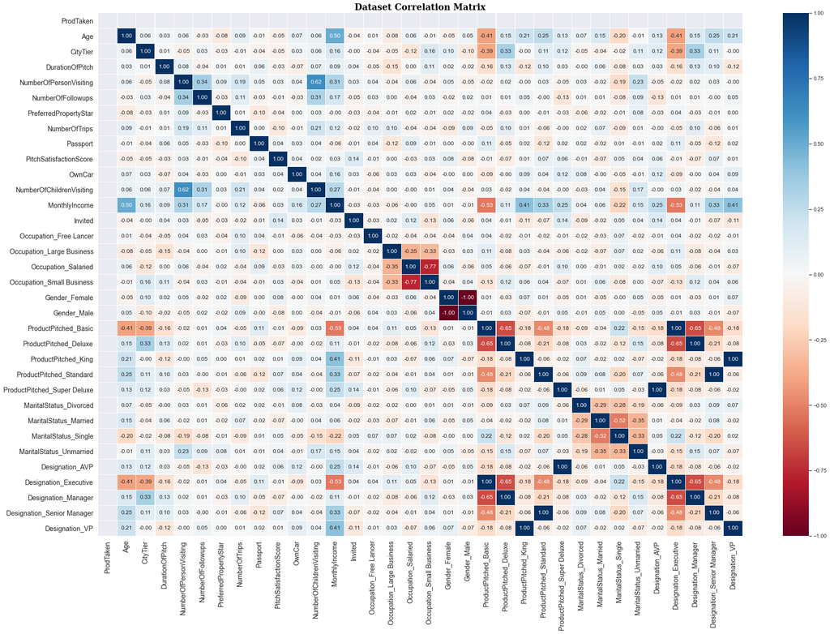

```python
#plot correlation matrix heatmap
fig, ax = plt.subplots(figsize=[30,20])
sns.heatmap(pd.get_dummies(dat_analysis).corr(), ax=ax,  annot=True, linewidths=0.05, fmt= '.2f',cmap="RdBu", vmin=-1, vmax=1)
ax.tick_params(axis='both', which='major', labelsize=14)
ax.set_title('Dataset Correlation Matrix', fontdict={'family': 'serif', 'color': 'black', 'size': 18, 'weight': 'bold'})
fig.show();
```

```python
#create dummie variables from boolean and integer categorical so that the model may perform better.
dat1 = pd.get_dummies(df)
```

```python
#look at nan and null values
dat1.isna().sum()[dat1.isna().sum()!= 0]
```

```
Age                         226
DurationOfPitch             251
NumberOfFollowups            45
PreferredPropertyStar        26
NumberOfTrips               140
NumberOfChildrenVisiting     66
MonthlyIncome               233
dtype: int64
```

Observations

There are several features that will need missing value treatment.

# Missing Value treatment employing KNNImputer

```python
dat_analysis.head()
```

|  | ProdTaken | Age | CityTier | DurationOfPitch | Occupation | Gender | NumberOfPersonVisiting | NumberOfFollowups | ProductPitched | PreferredPropertyStar | MaritalStatus | NumberOfTrips | Passport | PitchSatisfactionScore | OwnCar | NumberOfChildrenVisiting | Designation | MonthlyIncome | Invited |
| --- | --- | --- | --- | --- | --- | --- | --- | --- | --- | --- | --- | --- | --- | --- | --- | --- | --- | --- | --- |
| 0 | 1 | 41.0 | 3 | 6.0 | Salaried | Female | 3 | 3.0 | Deluxe | 3.0 | Single | 1.0 | 1 | 2 | 1 | 0.0 | Manager | 20993.0 | 0 |
| 2 | 1 | 37.0 | 1 | 8.0 | Free Lancer | Male | 3 | 4.0 | Basic | 3.0 | Single | 7.0 | 1 | 3 | 0 | 0.0 | Executive | 17090.0 | 0 |
| 14 | 1 | 28.0 | 1 | 30.0 | Salaried | Male | 2 | 4.0 | Basic | 3.0 | Single | 6.0 | 1 | 2 | 0 | 0.0 | Executive | 17028.0 | 0 |
| 21 | 1 | NaN | 3 | 15.0 | Salaried | Male | 2 | 4.0 | Deluxe | 5.0 | Single | 1.0 | 0 | 2 | 0 | 0.0 | Manager | 18407.0 | 0 |
| 24 | 1 | 34.0 | 1 | 12.0 | Small Business | Male | 2 | 3.0 | Basic | 5.0 | Single | 3.0 | 0 | 2 | 1 | 1.0 | Executive | 17960.0 | 0 |

```python
# work on copy of dataframe
dat2=dat1.copy()

#initialize imputer
imputer = KNNImputer(n_neighbors=3)

# Run imputer on dataframe
dat2[:] = imputer.fit_transform(dat2)
```

```python
a = dat1.describe().T
b = dat2.describe().T

comp = pd.DataFrame()

comp['before_mean'] = a['mean'].values
comp['after_mean'] = b['mean'].values
comp['before_std'] = a['std'].values
comp['after_std'] = b['std'].values
comp['before_min'] = a['min'].values
comp['after_min'] = b['min'].values
comp['before_25%'] = a['25%'].values
comp['after_25%'] = b['25%'].values
comp['before_50%'] = a['50%'].values
comp['after_50%'] = b['50%'].values
comp['before_75%'] = a['75%'].values
comp['after_75%'] = b['75%'].values
comp['before_max'] = a['max'].values
comp['after_max'] = b['max'].values
comp.set_index(a.index.values, inplace=True)
comp
```

|  | before_mean | after_mean | before_std | after_std | before_min | after_min | before_25% | after_25% | before_50% | after_50% | before_75% | after_75% | before_max | after_max |
| --- | --- | --- | --- | --- | --- | --- | --- | --- | --- | --- | --- | --- | --- | --- |
| ProdTaken | 0.188216 | 0.188216 | 0.390925 | 0.390925 | 0.0 | 0.0 | 0.0 | 0.0 | 0.0 | 0.0 | 0.0 | 0.0 | 1.0 | 1.0 |
| Age | 37.622265 | 37.572490 | 9.316387 | 9.191069 | 18.0 | 18.0 | 31.0 | 31.0 | 36.0 | 36.0 | 44.0 | 44.0 | 61.0 | 61.0 |
| CityTier | 1.654255 | 1.654255 | 0.916583 | 0.916583 | 1.0 | 1.0 | 1.0 | 1.0 | 1.0 | 1.0 | 3.0 | 3.0 | 3.0 | 3.0 |
| DurationOfPitch | 15.490835 | 15.463312 | 8.519643 | 8.391115 | 5.0 | 5.0 | 9.0 | 9.0 | 13.0 | 13.0 | 20.0 | 20.0 | 127.0 | 127.0 |
| NumberOfPersonVisiting | 2.905074 | 2.905074 | 0.724891 | 0.724891 | 1.0 | 1.0 | 2.0 | 2.0 | 3.0 | 3.0 | 3.0 | 3.0 | 5.0 | 5.0 |
| NumberOfFollowups | 3.708445 | 3.704651 | 1.002509 | 1.000142 | 1.0 | 1.0 | 3.0 | 3.0 | 4.0 | 4.0 | 4.0 | 4.0 | 6.0 | 6.0 |
| PreferredPropertyStar | 3.581037 | 3.583061 | 0.798009 | 0.797629 | 3.0 | 3.0 | 3.0 | 3.0 | 3.0 | 3.0 | 4.0 | 4.0 | 5.0 | 5.0 |
| NumberOfTrips | 3.236521 | 3.215494 | 1.849019 | 1.834197 | 1.0 | 1.0 | 2.0 | 2.0 | 3.0 | 3.0 | 4.0 | 4.0 | 22.0 | 22.0 |
| Passport | 0.290917 | 0.290917 | 0.454232 | 0.454232 | 0.0 | 0.0 | 0.0 | 0.0 | 0.0 | 0.0 | 1.0 | 1.0 | 1.0 | 1.0 |
| PitchSatisfactionScore | 3.078151 | 3.078151 | 1.365792 | 1.365792 | 1.0 | 1.0 | 2.0 | 2.0 | 3.0 | 3.0 | 4.0 | 4.0 | 5.0 | 5.0 |
| OwnCar | 0.620295 | 0.620295 | 0.485363 | 0.485363 | 0.0 | 0.0 | 0.0 | 0.0 | 1.0 | 1.0 | 1.0 | 1.0 | 1.0 | 1.0 |
| NumberOfChildrenVisiting | 1.187267 | 1.178737 | 0.857861 | 0.856075 | 0.0 | 0.0 | 1.0 | 1.0 | 1.0 | 1.0 | 2.0 | 2.0 | 3.0 | 3.0 |
| MonthlyIncome | 23619.853491 | 23482.205947 | 5380.698361 | 5314.774397 | 1000.0 | 1000.0 | 20346.0 | 20279.0 | 22347.0 | 22095.5 | 25571.0 | 25445.0 | 98678.0 | 98678.0 |
| Invited | 0.295417 | 0.295417 | 0.456277 | 0.456277 | 0.0 | 0.0 | 0.0 | 0.0 | 0.0 | 0.0 | 1.0 | 1.0 | 1.0 | 1.0 |
| Occupation_Free Lancer | 0.000409 | 0.000409 | 0.020226 | 0.020226 | 0.0 | 0.0 | 0.0 | 0.0 | 0.0 | 0.0 | 0.0 | 0.0 | 1.0 | 1.0 |
| Occupation_Large Business | 0.088789 | 0.088789 | 0.284468 | 0.284468 | 0.0 | 0.0 | 0.0 | 0.0 | 0.0 | 0.0 | 0.0 | 0.0 | 1.0 | 1.0 |
| Occupation_Salaried | 0.484452 | 0.484452 | 0.499809 | 0.499809 | 0.0 | 0.0 | 0.0 | 0.0 | 0.0 | 0.0 | 1.0 | 1.0 | 1.0 | 1.0 |
| Occupation_Small Business | 0.426350 | 0.426350 | 0.494597 | 0.494597 | 0.0 | 0.0 | 0.0 | 0.0 | 0.0 | 0.0 | 1.0 | 1.0 | 1.0 | 1.0 |
| Gender_Female | 0.403437 | 0.403437 | 0.490637 | 0.490637 | 0.0 | 0.0 | 0.0 | 0.0 | 0.0 | 0.0 | 1.0 | 1.0 | 1.0 | 1.0 |
| Gender_Male | 0.596563 | 0.596563 | 0.490637 | 0.490637 | 0.0 | 0.0 | 0.0 | 0.0 | 1.0 | 1.0 | 1.0 | 1.0 | 1.0 | 1.0 |
| ProductPitched_Basic | 0.376841 | 0.376841 | 0.484644 | 0.484644 | 0.0 | 0.0 | 0.0 | 0.0 | 0.0 | 0.0 | 1.0 | 1.0 | 1.0 | 1.0 |
| ProductPitched_Deluxe | 0.354337 | 0.354337 | 0.478361 | 0.478361 | 0.0 | 0.0 | 0.0 | 0.0 | 0.0 | 0.0 | 1.0 | 1.0 | 1.0 | 1.0 |
| ProductPitched_King | 0.047054 | 0.047054 | 0.211776 | 0.211776 | 0.0 | 0.0 | 0.0 | 0.0 | 0.0 | 0.0 | 0.0 | 0.0 | 1.0 | 1.0 |
| ProductPitched_Standard | 0.151800 | 0.151800 | 0.358864 | 0.358864 | 0.0 | 0.0 | 0.0 | 0.0 | 0.0 | 0.0 | 0.0 | 0.0 | 1.0 | 1.0 |
| ProductPitched_Super Deluxe | 0.069967 | 0.069967 | 0.255118 | 0.255118 | 0.0 | 0.0 | 0.0 | 0.0 | 0.0 | 0.0 | 0.0 | 0.0 | 1.0 | 1.0 |
| MaritalStatus_Divorced | 0.194354 | 0.194354 | 0.395743 | 0.395743 | 0.0 | 0.0 | 0.0 | 0.0 | 0.0 | 0.0 | 0.0 | 0.0 | 1.0 | 1.0 |
| MaritalStatus_Married | 0.478723 | 0.478723 | 0.499598 | 0.499598 | 0.0 | 0.0 | 0.0 | 0.0 | 0.0 | 0.0 | 1.0 | 1.0 | 1.0 | 1.0 |
| MaritalStatus_Single | 0.187398 | 0.187398 | 0.390270 | 0.390270 | 0.0 | 0.0 | 0.0 | 0.0 | 0.0 | 0.0 | 0.0 | 0.0 | 1.0 | 1.0 |
| MaritalStatus_Unmarried | 0.139525 | 0.139525 | 0.346529 | 0.346529 | 0.0 | 0.0 | 0.0 | 0.0 | 0.0 | 0.0 | 0.0 | 0.0 | 1.0 | 1.0 |
| Designation_AVP | 0.069967 | 0.069967 | 0.255118 | 0.255118 | 0.0 | 0.0 | 0.0 | 0.0 | 0.0 | 0.0 | 0.0 | 0.0 | 1.0 | 1.0 |
| Designation_Executive | 0.376841 | 0.376841 | 0.484644 | 0.484644 | 0.0 | 0.0 | 0.0 | 0.0 | 0.0 | 0.0 | 1.0 | 1.0 | 1.0 | 1.0 |
| Designation_Manager | 0.354337 | 0.354337 | 0.478361 | 0.478361 | 0.0 | 0.0 | 0.0 | 0.0 | 0.0 | 0.0 | 1.0 | 1.0 | 1.0 | 1.0 |
| Designation_Senior Manager | 0.151800 | 0.151800 | 0.358864 | 0.358864 | 0.0 | 0.0 | 0.0 | 0.0 | 0.0 | 0.0 | 0.0 | 0.0 | 1.0 | 1.0 |
| Designation_VP | 0.047054 | 0.047054 | 0.211776 | 0.211776 | 0.0 | 0.0 | 0.0 | 0.0 | 0.0 | 0.0 | 0.0 | 0.0 | 1.0 | 1.0 |

# Look at Outliers:

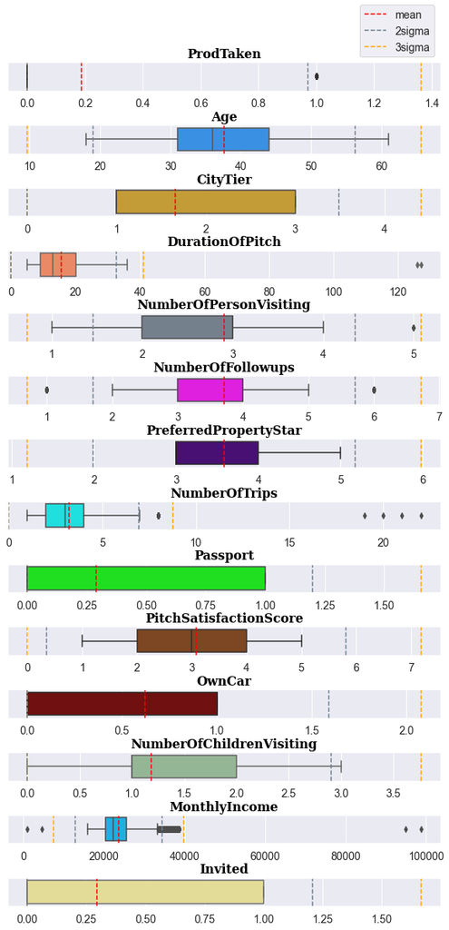

```python
blah = list(dat_analysis.dtypes != 'category')

#create fontdict for axis labels
axlab2 = {'family': 'serif',
              'color': 'black',
              'weight': 'bold',
              'size': 16
         }
#create subplot layout
fig = plt.figure(figsize=[10,20]);
x = list(dat_analysis.loc[:,blah].columns);
grid = plt.GridSpec(len(x), 1, wspace=0.3, hspace=1.2);
col = ['forestgreen','dodgerblue','goldenrod', 'coral', 'slategrey','magenta','indigo','cyan','lime','saddlebrown', 'maroon', 'darkseagreen','deepskyblue','khaki'];

#loop to populate boxplots within subplots
for i in np.arange(0,len(x)):
    for j in np.arange(0,1):
        exec(f'ax{i}{j} = plt.subplot(grid[i,j]);')
        exec(f'sns.boxplot(x=dat1[x[{i}]], ax=ax{i}{j}, color=col[{i}]);')
        exec(f'ax{i}{j}.set_title(x[{i}], fontdict=axlab2);')
        exec(f'ax{i}{j}.set_xlabel("", fontdict=axlab2);')
        exec(f'a{i} = ax{i}{j}.axvline(dat1[x[{i}]].mean(),color= "red", linestyle="--", label="mean")')
        exec(f'b{i} = ax{i}{j}.axvline(dat1[x[{i}]].mean()+ 3 * dat1[x[{i}]].std(),color= "orange", linestyle="--", label="3sigma")')
        exec(f'ax{i}{j}.axvline(max([dat1[x[{i}]].mean()- 3 * dat1[x[{i}]].std(), 0]),color= "orange", linestyle="--")')
        exec(f'c{i} = ax{i}{j}.axvline(dat1[x[{i}]].mean()+ 2 * dat1[x[{i}]].std(),color= "slategrey", linestyle="--", label="2sigma")')
        exec(f'ax{i}{j}.axvline(max([dat1[x[{i}]].mean()- 2 * dat1[x[{i}]].std(), 0]),color= "slategrey", linestyle="--")')
        plt.xticks(fontsize=14);

plt.legend([a0, c0, b0], ['mean','2sigma','3sigma'], loc='upper center', bbox_to_anchor=(0.9, 31.8), fontsize=14)
fig.show();
```

```python
#creating a sample_weights array based upon demographic data from the Jamaica study on tourism
samp_weights = []
for i in np.arange(0,len(dat2)):
    blah = 0
    # Calculate weight factor for age
    if dat2.loc[i,'Age'] <= 24:
        blah += 8
    elif np.logical_and(dat2.loc[i,'Age'] > 24, dat2.loc[i,'Age'] <= 34):
        blah += 23
    elif np.logical_and(dat2.loc[i,'Age'] > 34, dat2.loc[i,'Age'] <= 49):
        blah += 34
    elif np.logical_and(dat2.loc[i,'Age'] > 49, dat2.loc[i,'Age'] <= 64):
        blah += 28
    else:
        blah += 6

    #caclulate weight factor for gender
    if dat2.loc[i,'Gender_Female'] == 1:
        blah += 42
    else:
        blah += 58

    #calculate weight factor for income
    if dat2.loc[i,'MonthlyIncome'] <= 25000:
        blah += 74
    elif np.logical_and(dat2.loc[i,'MonthlyIncome'] > 25000, dat2.loc[i,'MonthlyIncome'] <= 50000):
        blah += 9
    elif np.logical_and(dat2.loc[i,'MonthlyIncome'] > 50000, dat2.loc[i,'MonthlyIncome'] <= 75000):
        blah += 7
    elif np.logical_and(dat2.loc[i,'MonthlyIncome'] > 75000, dat2.loc[i,'MonthlyIncome'] <= 100000):
        blah += 4
    else:
        blah += 7
    #calculate weight factor for 'MaritalStatus_Married
    if np.logical_or(dat2.loc[i,'MaritalStatus_Married'] == 1, dat2.loc[i,'MaritalStatus_Single'] == 1):
        blah += 53

    #calculate weight factor for children
    if dat2.loc[i, 'NumberOfChildrenVisiting'] > 0:
        blah += 21

    #calculate weight for travelling alone (this is a likelihood guess here)
    if np.logical_and(np.logical_and(dat2.loc[i,'MaritalStatus_Married'] == 0, dat2.loc[i,'MaritalStatus_Single'] == 0), dat2.loc[i,'NumberOfChildrenVisiting'] == 0):
        blah += 12

    #caclulate weight for domestic vs. international possibility (domestic weighting factor 82, international 82+18)
    #this was determined from the statistic that 82% of welness trips were domestic, so if a potential traveller
    #doesnt have a passport, they are not part of the international travel group (18%) are are weighted at 82, not 100
    if dat2.loc[i, 'Passport'] == 1:
        blah += 100
    else:
        blah += 82

    samp_weights.append(blah)
```

```python
pd.DataFrame(samp_weights, columns=['Sample Weights']).describe()
```

|  | Sample Weights |
| --- | --- |
| count | 4888.000000 |
| mean | 274.893412 |
| std | 39.070716 |
| min | 168.000000 |
| 25% | 251.000000 |
| 50% | 275.000000 |
| 75% | 311.000000 |
| max | 340.000000 |

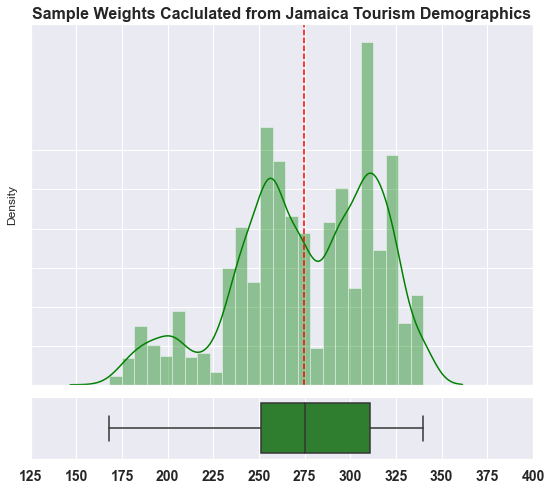

```python
fig = plt.figure(figsize=[9,8])
grid = plt.GridSpec(6, 1, wspace=0.3, hspace=0.2)

ax0 = plt.subplot(grid[0:5, 0])
sns.distplot(samp_weights, ax=ax0, color='green');
ax0.axvline(np.mean(samp_weights),color= "red", linestyle="--", label="mean")
plt.title('Sample Weights Caclulated from Jamaica Tourism Demographics', fontsize = 16, fontweight='bold');
plt.xticks(np.arange(125,401,25),labels=['','','','','','','','','','','',''])
plt.yticks(np.arange(0,0.0121,0.002),labels=['','','','','','',''])
ax1 = plt.subplot(grid[5, 0])
sns.boxplot(x = samp_weights, ax=ax1, color='forestgreen')
plt.xticks(np.arange(125,401,25),labels=['125','150','175','200','225','250','275','300','325','350','375','400'], fontsize=14, fontweight='bold');
```

# Prediction of reliable model accuracy from sample weights

```python
#generate boolean fields to look at ProdTaken=1 when weights are above mean for the purpose of making a prediction
#about where to expect the accuracy of the model to make a presumption about how closely the model follows the
#sample weights.
samp_bool = []
for i in np.arange(0,len(samp_weights)):
    if samp_weights[i] > np.mean(samp_weights):
        samp_bool.append(1)
    else:
        samp_bool.append(0)

samp_bool = samp_bool*dat2['ProdTaken']
```

```python
#make approximation of ideal accuracy score using sample weights. The idea here is that weights above the mean
#are accurate predictions of wellness tourists
(samp_bool == dat2['ProdTaken']).sum()/len(dat2['ProdTaken'])
```

```
0.929214402618658
```

```python
#drop dummy variables that will cause overfitting
#also dropping PitchSatisfactionScore because it is not helpful because the information is gained after the pitch
dat2.drop(columns=['Occupation_Free Lancer', 'Gender_Male','ProductPitched_Super Deluxe','MaritalStatus_Unmarried','Designation_Senior Manager','PitchSatisfactionScore'], inplace=True)
dat2['samp_weights'] = samp_weights
```

# Splitting the data

```python
X = dat2.drop(columns=['ProdTaken'])
y = dat2['ProdTaken']
#Perform 50/50 test train split
X_train, X_test, y_train, y_test = train_test_split(X, y, test_size=.5, random_state=42)
fit_weights_train = X_train['samp_weights']
fit_weights_test = X_test['samp_weights']
X_train.drop(columns=['samp_weights'], inplace=True)
X_test.drop(columns=['samp_weights'], inplace=True)
```

```python
#the below function displays performance metrics for each model as CVGridSearch performs cross validation
def evaluate_model(name, model, features, labels):
    beg = datetime.datetime.now()
    pred = model.predict(features)
    end = datetime.datetime.now()
    accuracy = round(accuracy_score(labels, pred), 3)
    precision = round(precision_score(labels, pred), 3)
    recall = round(recall_score(labels, pred), 3)
    print('{} -- Accuracy: {} / Precision: {} / Recall: {} / Latency: {}ms'.format(name, accuracy, precision, recall, (end-beg).microseconds/1000))
```

```python
#the below function displays performance metrics of best model calculated through CVGridSearch
def print_results(results):
    print('BEST PARAMETERS: {}\n'.format(results.best_params_))

    means = results.cv_results_['mean_test_score']
    stds = results.cv_results_['std_test_score']
    for mean, std, params in zip(means, stds, results.cv_results_['params']):
        print('{} (+/-{}) for {}'.format(round(mean, 3), round(std * 2, 3), params))
```

```python
#Function to calculate recall score
def get_recall_score(model, train, test):
    pred_train = model.predict(train)
    pred_test = model.predict(test)
    print("Recall on training set : ",metrics.recall_score(y_train,pred_train))
    print("Recall on test set : ",metrics.recall_score(y_test,pred_test))
```

```python
#the below function generated confusion matrix
def make_confusion_matrix(y_actual,y_predict,labels=[1, 0]):
    cm=confusion_matrix( y_actual,y_predict, labels=[1, 0])
    df_cm = pd.DataFrame(cm, index = [i for i in ["1","0"]],
                  columns = [i for i in ['Product Taken','Product Not Taken']])
    group_counts = ["{0:0.0f}".format(value) for value in
                cm.flatten()]
    group_percentages = ["{0:.2%}".format(value) for value in
                         cm.flatten()/np.sum(cm)]
    labels = [f"{v1}\n{v2}" for v1, v2 in
              zip(group_counts,group_percentages)]
    labels = np.asarray(labels).reshape(2,2)
    fig = plt.figure(figsize = (10,7))
    hmp = sns.heatmap(df_cm, annot=labels,fmt='')
    hmp.set_xticklabels(hmp.get_xmajorticklabels(), fontsize = 14, fontweight='bold')
    hmp.set_yticklabels(hmp.get_ymajorticklabels(), fontsize = 14, fontweight='bold')
    plt.ylabel('True label', fontsize = 14, fontweight='bold')
    plt.xlabel('Predicted label',fontsize = 14, fontweight='bold')
```

```python
# compute optimal class weight using sklearn function
class_weights = compute_class_weight('balanced', [0,1], y)
```

```python
class_weights
```

```
array([0.61592742, 2.65652174])
```

# Decision Tree Classification Model

```python
#parameter grid for CVGridSearch to iterate through to tune hyperparameters
params = {'max_depth': list(np.arange(2,20)) + [None],
          'min_samples_leaf': [1, 3, 5, 7, 10],
          'max_leaf_nodes' : [2, 3, 5, 10, 15] + [None],
          'min_impurity_decrease': [0.001, 0.01, 0.1, 0.0]
          }

#initialize decision tree classifier solver
dt = DecisionTreeClassifier(random_state=42)

#initialize grid search by inputting model, paramter grid, and # of folds in cross validation
cv = GridSearchCV(dt, params, cv=5)

#Fit the model to the training data
cv.fit(X_train, y_train, sample_weight=fit_weights_train)
dtree = cv.best_estimator_
```

```python
evaluate_model('Decision Tree', cv.best_estimator_, X_test, y_test)
```

```
Decision Tree -- Accuracy: 0.852 / Precision: 0.636 / Recall: 0.436 / Latency: 3.003ms
```

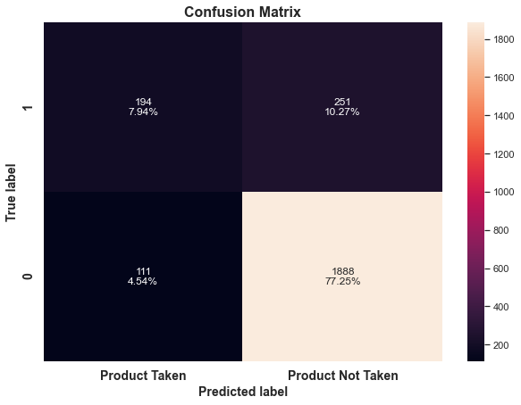

```python
make_confusion_matrix(y_test, cv.best_estimator_.predict(X_test))
plt.title('Confusion Matrix', fontsize=16, fontweight='bold');
```

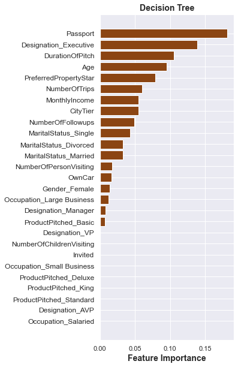

```python
feature_names = X_train.columns
importances = dtree.feature_importances_
indices = np.argsort(importances);
fig=plt.figure(figsize=[4,10]);
plt.title('Decision Tree', fontsize=14, fontweight='bold');
plt.barh(range(len(indices)), importances[indices], align='center', color='saddlebrown');
plt.yticks(range(len(indices)), [feature_names[i] for i in indices], fontsize=12);
plt.xlabel('Feature Importance', fontsize=14, fontweight='bold');
```

# Bagging Classifier

```python
#parameter grid for CVGridSearch to iterate through to tune hyperparameters
params = {'base_estimator': [DecisionTreeClassifier(criterion='gini',class_weight={0: class_weights[0], 1: class_weights[1]},random_state=42)],
          'n_estimators': [50, 80, 100, 120],
          'max_samples': np.arange(0.6,0.91,0.1),
          'max_features': np.arange(0.6,0.91,0.1),
          'bootstrap': [False],
          'bootstrap_features': [False]}

#initialize bagging classifier solver
bc = BaggingClassifier(random_state=42)

#initialize grid search by inputting model, paramter grid, and # of folds in cross validation
cv = GridSearchCV(bc, params, cv=5)

#Fit the model to the training data
cv.fit(X_train, y_train, sample_weight=fit_weights_train)
bagging = cv.best_estimator_
```

```python
evaluate_model('Bagging', cv.best_estimator_, X_test, y_test)
```

```
Bagging -- Accuracy: 0.886 / Precision: 0.764 / Recall: 0.539 / Latency: 49.936ms
```

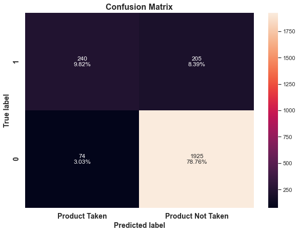

```python
make_confusion_matrix(y_test, cv.best_estimator_.predict(X_test))
plt.title('Confusion Matrix', fontsize=16, fontweight='bold');
```

# RandomForest Classifier

```python
#parameter grid for CVGridSearch to iterate through to tune hyperparameters
params = {'max_depth':[4, 6, 8, 10, None],
          'max_features': ['sqrt','log2',None],
          'n_estimators': [80, 90, 100, 110, 120]}

#initialize bagging classifier solver
rf = RandomForestClassifier(random_state=42)

#initialize grid search by inputting model, paramter grid, and # of folds in cross validation
cv = GridSearchCV(rf, params, cv=5)

#Fit the model to the training data
cv.fit(X_train, y_train, sample_weight=fit_weights_train)
randfor = cv.best_estimator_
```

```python
evaluate_model('Random Forest', cv.best_estimator_, X_test, y_test)
```

```
Random Forest -- Accuracy: 0.887 / Precision: 0.751 / Recall: 0.571 / Latency: 26.201ms
```

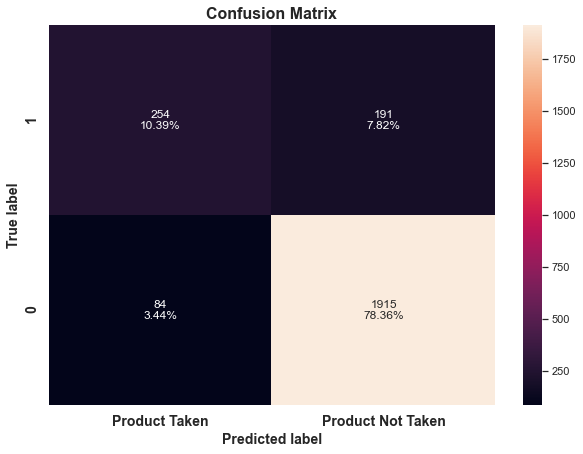

```python
make_confusion_matrix(y_test, cv.best_estimator_.predict(X_test))
plt.title('Confusion Matrix', fontsize=16, fontweight='bold');
```

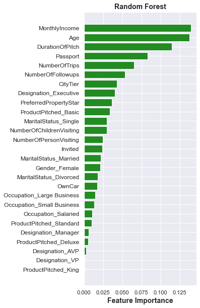

```python
feature_names = X_train.columns
importances = randfor.feature_importances_
indices = np.argsort(importances)
fig=plt.figure(figsize=[4,10]);
plt.title('Random Forest', fontsize=14, fontweight='bold');
plt.barh(range(len(indices)), importances[indices], align='center', color='forestgreen');
plt.yticks(range(len(indices)), [feature_names[i] for i in indices], fontsize=12);
plt.xlabel('Feature Importance', fontsize=14, fontweight='bold');
```

# AdaBoost Classifier

```python
#parameter grid for CVGridSearch to iterate through to tune hyperparameters
params = {'n_estimators': np.arange(10,100,10),
          'learning_rate': [1, 0.1, 0.5, 0.01]}

#initialize bagging classifier solver
ab = AdaBoostClassifier(random_state=42)

#initialize grid search by inputting model, paramter grid, and # of folds in cross validation
cv = GridSearchCV(ab, params, cv=5)

#Fit the model to the training data
cv.fit(X_train, y_train, sample_weight=fit_weights_train)
ada = cv.best_estimator_
```

```python
evaluate_model('AdaBoost', cv.best_estimator_, X_test, y_test)
```

```
AdaBoost -- Accuracy: 0.843 / Precision: 0.667 / Recall: 0.274 / Latency: 43.243ms
```

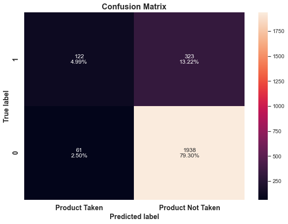

```python
make_confusion_matrix(y_test, cv.best_estimator_.predict(X_test))
plt.title('Confusion Matrix', fontsize=16, fontweight='bold');
```

# Gradient Boosting Classifier

```python
#parameter grid for CVGridSearch to iterate through to tune hyperparameters
params = {'n_estimators': np.arange(50,200,25),
          'subsample':[0.7,0.8,0.9,1],
          'max_features':[0.7,0.8,0.9,1],
          'max_depth':[3,5,7,10]}

#initialize bagging classifier solver
gb = GradientBoostingClassifier(random_state=42)

#initialize grid search by inputting model, paramter grid, and # of folds in cross validation
cv = GridSearchCV(gb, params, cv=5)

#Fit the model to the training data
cv.fit(X_train, y_train, sample_weight=fit_weights_train)
gradboost = cv.best_estimator_
```

```python
evaluate_model('Gradient Boosting', cv.best_estimator_, X_test, y_test)
```

```
Gradient Boosting -- Accuracy: 0.905 / Precision: 0.815 / Recall: 0.616 / Latency: 11.002ms
```

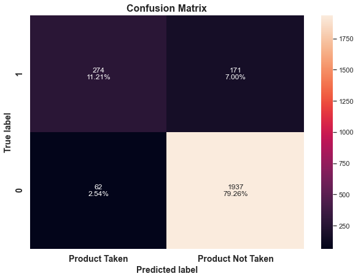

```python
make_confusion_matrix(y_test, cv.best_estimator_.predict(X_test))
plt.title('Confusion Matrix', fontsize=16, fontweight='bold');
```

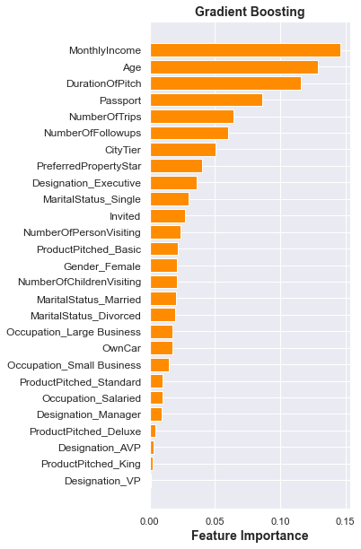

```python
feature_names = X_train.columns
importances = gradboost.feature_importances_
indices = np.argsort(importances)
fig=plt.figure(figsize=[4,10]);
plt.title('Gradient Boosting', fontsize=14, fontweight='bold');
plt.barh(range(len(indices)), importances[indices], align='center', color='darkorange');
plt.yticks(range(len(indices)), [feature_names[i] for i in indices], fontsize=12);
plt.xlabel('Feature Importance', fontsize=14, fontweight='bold');
```

# XGBoost Classifier.

```python
#parameter grid for CVGridSearch to iterate through to tune hyperparameters
params = {'n_estimators': [75,100,125,150],
          'subsample':[0.7, 0.8, 0.9, 1],
          'gamma':[0, 1, 3, 5],
          'colsample_bytree':[0.7, 0.8, 0.9, 1],
          'colsample_bylevel':[0.7, 0.8, 0.9, 1]}

#initialize XBBoost classifier solver
Xgb = XGBClassifier(random_state=42, eval_metric='logloss')

#initialize grid search by inputting model, paramter grid, and # of folds in cross validation
cv = GridSearchCV(Xgb, params, cv=5)

#Fit the model to the training data
cv.fit(X_train, y_train, sample_weight=fit_weights_train)
Xgboost = cv.best_estimator_
```

```python
evaluate_model('XGBoost', cv.best_estimator_, X_test, y_test)
```

```
XGBoost -- Accuracy: 0.898 / Precision: 0.783 / Recall: 0.607 / Latency: 5.999ms
```

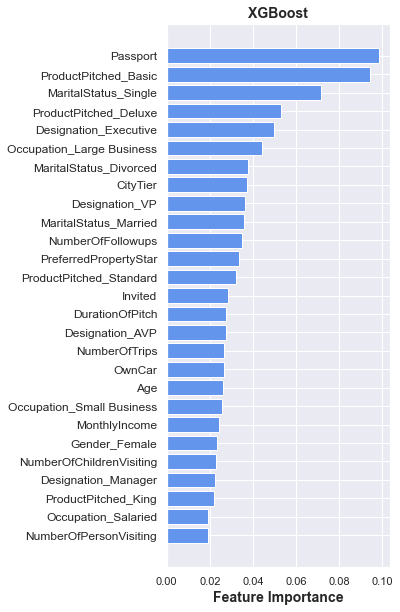

```python
feature_names = X_train.columns
importances = Xgboost.feature_importances_
indices = np.argsort(importances)
fig=plt.figure(figsize=[4,10]);
plt.title('XGBoost', fontsize=14, fontweight='bold');
plt.barh(range(len(indices)), importances[indices], align='center', color='cornflowerblue');
plt.yticks(range(len(indices)), [feature_names[i] for i in indices], fontsize=12);
plt.xlabel('Feature Importance', fontsize=14, fontweight='bold');
```

# Stacking Classifier

```python
estimators=[('Decision Tree', dtree),('Random Forest', randfor),('Gradient Boosting', gradboost)]
final_estimator=AdaBoostClassifier(random_state=42)

stacking=StackingClassifier(estimators=estimators, final_estimator=final_estimator,cv=5)
stacking.fit(X_train,y_train, sample_weight=fit_weights_train)
```

```
StackingClassifier(cv=5,
                   estimators=[('Decision Tree',
                                DecisionTreeClassifier(max_depth=11,
                                                       min_impurity_decrease=0.001,
                                                       random_state=42)),
                               ('Random Forest',
                                RandomForestClassifier(max_features=None,
                                                       n_estimators=80,
                                                       random_state=42)),
                               ('Gradient Boosting',
                                GradientBoostingClassifier(max_depth=10,
                                                           max_features=0.7,
                                                           n_estimators=50,
                                                           random_state=42,
                                                           subsample=0.9))],
                   final_estimator=AdaBoostClassifier(random_state=42))
```

```python
evaluate_model('Stacking', stacking, X_test, y_test)
```

```
Stacking -- Accuracy: 0.903 / Precision: 0.784 / Recall: 0.645 / Latency: 56.003ms
```

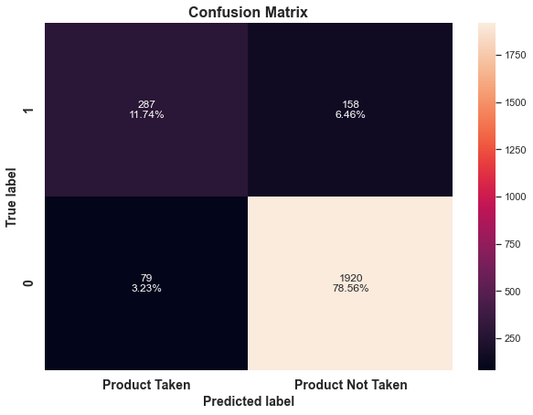

```python
make_confusion_matrix(y_test, stacking.predict(X_test))
plt.title('Confusion Matrix', fontsize=16, fontweight='bold');
```

# Summary and Recommendations for the Business

For the current travel packages oit is recommended that marketing is aimed as follows:

Age:

Basic - Predominately in 20s, also 30s and 40s Standard & Deluxe - Predominately in 30s, also 40s Super Deluxe - Predominately in 40s, also 50s King - 30s, 40s, but predominately in 50s

Income: Basic - 15k - 25k Deluxe - 20k - 30k Standard - 20k - 35k Super Deluxe - 25k - 35k King - 30k - 45k

Marital Status: Basic - Single, Divorced, Unmarried, & Married Deluxe - Single, Divorced, Unmarried, & Married Standard - Divorced, Unmarried, & Married Super Deluxe - Single & Married King - Single, Divorced, & Married

City Tier

Basic - 1, 2, & 3 Deluxe - 1 & 3 Standard - 1 & 3 Super Deluxe - 3 King - 1 & 3 Gender No Gender Specificity

# of Persons

Basic, Deluxe, Standard, & King - 2, 3, & 4 Super Deluxe - 2 & 3

Occupation

Basic, Deluxe, Standard, & King - Salaried, Small Business, and Large Business Super Deluxe - Salaried & Small Business Freelancers very unlikely to purchase travel package

Preferred Property Scores Basic - 3, 4, & 5 Deluxe, Standard, and Super Deluxe - Predominately 3 King - 3 & 4 but predominately 4

Passport

Basic more likely for International Travel Designation Basic - Executive Deluxe - Manager Standard - Senior Manager Super Deluxe - AVP King - VP

Follow-ups

Expect 3-5 follow-ups before purchase On Average: Basic, Deluxe, Standard, & King - 4 follow-ups Super Deluxe - 3 ** There is some indication that by increasing follow-ups to at least 4, this may result in an uptick in sales.

Pitch Satisfaction Score

There appears to be a problem with the survey for pitch satisfaction which is indicating satisfaction scores that are inconsistent with purchasing behavior. This may be due to a misunderstanding in which rating is god or bad. Recommend switch to Excellent, Good, Average, Poor scoring to get better feedback.

# of children visiting

More sales when <= 2, but overall indeterminate.

Own Car Super Deluxe & King - Yes All others, indeterminate

Pitch Time Recommendations: Basic, Standard, Deluxe, and Super Deluxe - ~20 minutes King - ~10 minutes

Conversion Rates

Basic - 30% Standard - 15% Deluxe - 10% Super Deluxe - 5% -->Uptick may be obtained by increasing # of follow-ups to at least 4 King - 8%